# Import and Tidy ADFG Supplied Location and Haul-out Data

This article describes the import and tidying of location and haul-out data provided to MML by ADFG for use in manuscript analyzing haul-out behavior of bearded, ribbon, and spotted seals in the Bering and Chukchi seas

Josh M. London https://github.com/jmlondon (Alaska Fisheries Science Center)https://www.fisheries.noaa.gov/about/alaska-fisheries-science-center , Justin Crawford http://www.adfg.alaska.gov/index.cfm%3Fadfg%3Dmarinemammalprogram.icesealresearch (Alaska Department of Fish & Game)http://www.adfg.alaska.gov  
May 6, 2021

## Introduction

The focus of this document is not to analyze the data, but instead to document the processing of the ‘raw’ data (as provided) into a usable data structure for downstream merging with other datasets and analysis procedures. We will focus on reading in the csv files, tidying any data structures or values that need it, and then merging into a single usable tibble.

## Read the CSV Files

There are three files provided by ADF&G

1. ADFG_SealDeploymentTable3.csv
2. ADFG_SealLocationData3.csv
3. ADFG_SealTimelineData3.csv

### ADFG Seal Deployments

Let’s read this file in and take a look at the structure

```r
adfg_deployments <- readr::read_csv('ADFG_SealDeploymentTable3.csv')
```

Let’s look at some of the data and see if we might want to adjust some of the automatically determined column specifications

```r
glimpse(adfg_deployments)
```

```
Rows: 55
Columns: 8
$ DeployIDs      <chr> "EB14KKA-136707", "EB14KKA-136713", "EB14OTZ-…
$ MapID          <chr> "BS14-02-M", "BS14-04-M", "BS14-01-M", "BS15-…
$ DateTagged     <chr> "9/26/2014 0:00", "9/30/2014 0:00", "6/18/201…
$ Species        <chr> "Bearded", "Bearded", "Bearded", "Bearded", "…
$ Age            <chr> "Pup", "Pup", "Pup", "Yearling", "Yearling", …
$ Sex            <chr> "Male", "Male", "Male", "Male", "Female", "Fe…
$ PrimaryTagType <chr> "SPLASH", "SPLASH", "SPLASH", "SPLASH", "SPOT…
$ FlipperTagType <chr> "SPOT", "SPOT", "SPOT", "SPOT", NA, "SPOT", "…
```

```r
adfg_deploy_cols <- readr::cols(
  DeployIDs = readr::col_character(),
  MapID = readr::col_character(),
  DateTagged = readr::col_datetime(format = "%m/%d/%Y %H:%M"),
  Species = readr::col_character(),
  Age = readr::col_character(),
  Sex = readr::col_character(),
  PrimaryTagType = readr::col_character(),
  FlipperTagType = readr::col_character()
)

adfg_deployments <- readr::read_csv('ADFG_SealDeploymentTable3.csv',
                                    col_types = adfg_deploy_cols) %>%
  dplyr::mutate(DateTagged = lubridate::force_tz(DateTagged,
                                                 'America/Anchorage')) %>%
  dplyr::mutate(DateTagged = lubridate::as_datetime(DateTagged,
                                                tz = 'America/Anchorage'))

glimpse(adfg_deployments)
```

```
Rows: 55
Columns: 8
$ DeployIDs      <chr> "EB14KKA-136707", "EB14KKA-136713", "EB14OTZ-…
$ MapID          <chr> "BS14-02-M", "BS14-04-M", "BS14-01-M", "BS15-…
$ DateTagged     <dttm> 2014-09-26, 2014-09-30, 2014-06-18, 2015-08-…
$ Species        <chr> "Bearded", "Bearded", "Bearded", "Bearded", "…
$ Age            <chr> "Pup", "Pup", "Pup", "Yearling", "Yearling", …
$ Sex            <chr> "Male", "Male", "Male", "Male", "Female", "Fe…
$ PrimaryTagType <chr> "SPLASH", "SPLASH", "SPLASH", "SPLASH", "SPOT…
$ FlipperTagType <chr> "SPOT", "SPOT", "SPOT", "SPOT", NA, "SPOT", "…
```

The first author (JML) likes to stick with snake case for column names and variables. So, we’ll do some additional editing of the data to rename columns. While at it, we’ll also convert some of the columns to lower case to limit typo issues down the road.

Another issue we need to tidy up is the way satellite tag type and attachment position is recorded in the dataset. These data are stored within two columns: `primary_tag_type` and `flipper_tag_type`. For a proper tidy structure, we need to get these data into two columns: `tag_position` and `tag_type`. To do this, we’ll use the `tidyr::gather` function.

```r
adfg_deployments <- adfg_deployments %>%
  dplyr::rename(speno = DeployIDs,
                mapid = MapID,
                deploy_dt = DateTagged,
                primary_tag_type = PrimaryTagType,
                flipper_tag_type = FlipperTagType
                ) %>%
  dplyr::rename_all(tolower) %>%
  dplyr::mutate(species = tolower(species),
                age = tolower(age),
                sex = tolower(sex)) %>%
  tidyr::gather(tag_position, tag_family, c(primary_tag_type,flipper_tag_type)) %>%
  dplyr::mutate(tag_position = ifelse(tag_position == "primary_tag_type",
                   "primary","flipper")) %>%
  dplyr::filter(!is.na(tag_family)) %>%
  dplyr::arrange(deploy_dt)

glimpse(adfg_deployments)
```

```
Rows: 74
Columns: 8
$ speno        <chr> "KOTP-160-07", "KOTP-588-07", "KOTP-594-07", "K…
$ mapid        <chr> "RS07-04-F", "RS07-10-F", "RS07-14-M", "RS07-06…
$ deploy_dt    <dttm> 2007-10-14, 2007-10-21, 2007-10-21, 2007-10-25…
$ species      <chr> "ringed", "ringed", "ringed", "ringed", "ringed…
$ age          <chr> "adult", "adult", "subadult", "adult", "adult",…
$ sex          <chr> "female", "female", "male", "male", "female", "…
$ tag_position <chr> "primary", "primary", "primary", "primary", "pr…
$ tag_family   <chr> "SPLASH", "SPOT", "SPLASH", "SPLASH", "SPOT", "…
```

### ADFG Seal Locations

Next, we’ll go through a similar process with the locations data.

```r
adfg_locations <- readr::read_csv('ADFG_SealLocationData3.csv')
```

```r
glimpse(adfg_locations)
```

```
Rows: 26,049
Columns: 8
$ DeployID        <chr> "EB14KKA-136707", "EB14KKA-136707", "EB14KKA…
$ LocationQuality <chr> "1", "2", "1", "B", "B", "A", "2", "1", "2",…
$ Date            <dbl> 42038.93, 42038.95, 42038.95, 42041.18, 4205…
$ Latitude        <dbl> 63.96, 63.95, 63.96, 63.97, 63.95, 63.92, 63…
$ Longitude       <dbl> -162.45, -162.37, -162.36, -162.43, -162.60,…
$ Ptt             <dbl> 138006, 138006, 138006, 138006, 138006, 1380…
$ TagType         <chr> "SPOT", "SPOT", "SPOT", "SPOT", "SPOT", "SPO…
$ MonthNumb       <chr> "02", "02", "02", "02", "02", "02", "02", "0…
```

As with the deployment data, the `Date` column needs to be converted to a proper date-time type. Additionally, we can see that `Ptt` was brought in as a `double` when, in fact, this is an `integer`. There is no way to do the `Date` or `Ptt` type conversion via the `readr::col_*` functions, so we will do a mutate after reading the data in.

```r
adfg_locs_cols <- readr::cols(
  DeployID = readr::col_character(),
  LocationQuality = readr::col_character(),
  Date = readr::col_double(),
  Latitude = readr::col_double(),
  Longitude = readr::col_double(),
  Ptt = readr::col_double(),
  TagType = readr::col_character(),
  MonthNumb = readr::col_character()
)

adfg_locations <- readr::read_csv('ADFG_SealLocationData3.csv',
                                  col_types = adfg_locs_cols) %>%
  dplyr::mutate(Date = as.Date(Date, origin = "1899-12-30", tz ="UTC") %>%
                  lubridate::as_datetime(),
                Ptt = as.integer(Ptt))

glimpse(adfg_locations)
```

```
Rows: 26,049
Columns: 8
$ DeployID        <chr> "EB14KKA-136707", "EB14KKA-136707", "EB14KKA…
$ LocationQuality <chr> "1", "2", "1", "B", "B", "A", "2", "1", "2",…
$ Date            <dttm> 2015-02-03 22:25:52, 2015-02-03 22:42:36, 2…
$ Latitude        <dbl> 63.96, 63.95, 63.96, 63.97, 63.95, 63.92, 63…
$ Longitude       <dbl> -162.45, -162.37, -162.36, -162.43, -162.60,…
$ Ptt             <int> 138006, 138006, 138006, 138006, 138006, 1380…
$ TagType         <chr> "SPOT", "SPOT", "SPOT", "SPOT", "SPOT", "SPO…
$ MonthNumb       <chr> "02", "02", "02", "02", "02", "02", "02", "0…
```

As before, we’ll rename a few columns to snake_case and then all to lower case.

```r
adfg_locations <- adfg_locations %>%
  dplyr::rename(speno = DeployID,
                quality = LocationQuality,
                locs_dt = Date,
                tag_family = TagType) %>%
  dplyr::filter(quality != "Z") %>%
  dplyr::select(-MonthNumb) %>%
  dplyr::rename_all(tolower) %>%
  dplyr::left_join(adfg_deployments, by = c("speno","tag_family")) %>%
  mutate(species_code = case_when(
        species == "bearded" ~ "EB",
        species == "ribbon" ~ "HF",
        species == "spotted" ~ "PL"
    )) %>%
    mutate(deployid = glue::glue("{species_code}",
                            "{lubridate::year(deploy_dt)}_{ptt}")) %>%
    mutate(unique_day =
             glue::glue("{lubridate::year(locs_dt)}",
                  "{lubridate::yday(locs_dt)}",
                  .sep = "_")) %>%
  select(-species_code) %>%
  relocate(deployid,ptt) %>%
  filter(species %in% c('bearded', 'ribbon', 'spotted')) %>%
    filter(lubridate::month(locs_dt) %in% c(3,4,5,6,7)) %>%
  sf::st_as_sf(coords = c("longitude","latitude")) %>%
  sf::st_set_crs(value = "EPSG:4326")

glimpse(adfg_locations)
```

```
Rows: 5,627
Columns: 14
$ deployid     <glue> "EB2014_138006", "EB2014_138006", "EB2014_1380…
$ ptt          <int> 138006, 138006, 138006, 138006, 138006, 138006,…
$ speno        <chr> "EB14KKA-136707", "EB14KKA-136707", "EB14KKA-13…
$ quality      <chr> "1", "3", "A", "0", "B", "3", "1", "1", "0", "0…
$ locs_dt      <dttm> 2015-03-10 21:17:27, 2015-03-10 21:21:48, 2015…
$ tag_family   <chr> "SPOT", "SPOT", "SPOT", "SPOT", "SPOT", "SPOT",…
$ mapid        <chr> "BS14-02-M", "BS14-02-M", "BS14-02-M", "BS14-02…
$ deploy_dt    <dttm> 2014-09-26, 2014-09-26, 2014-09-26, 2014-09-26…
$ species      <chr> "bearded", "bearded", "bearded", "bearded", "be…
$ age          <chr> "pup", "pup", "pup", "pup", "pup", "pup", "pup"…
$ sex          <chr> "male", "male", "male", "male", "male", "male",…
$ tag_position <chr> "flipper", "flipper", "flipper", "flipper", "fl…
$ unique_day   <glue> "2015_69", "2015_69", "2015_79", "2015_81", "2…
$ geometry     <POINT [°]> POINT (-162.21 63.87), POINT (-162.07 63.…
```

At this point, we have our locations data assembled. Let’s take a moment and plot all the data on a map

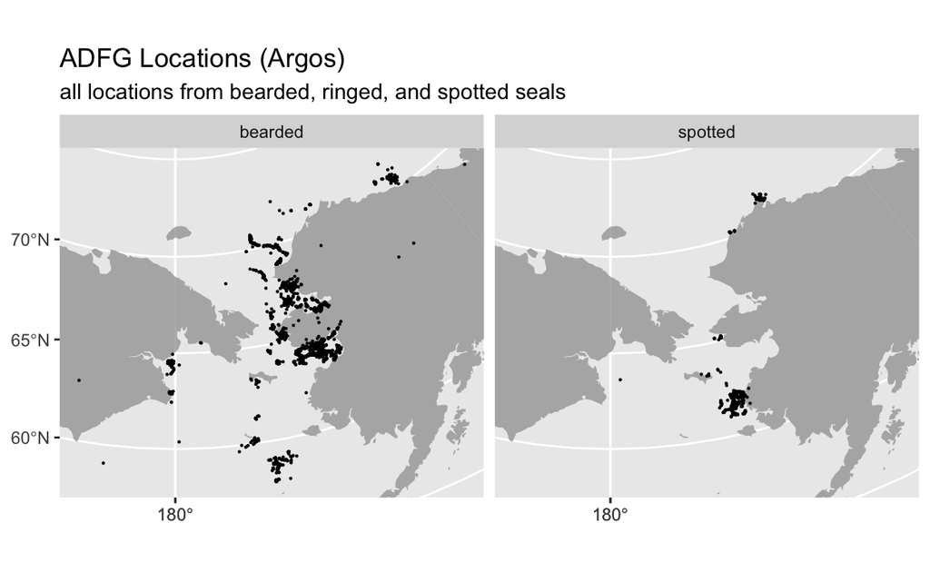

```r
library(sf)
library(rnaturalearth)
library(ggspatial)

world <- ne_countries(scale = "medium", returnclass = "sf") %>%
  sf::st_transform(3571)

ggplot() +
  annotation_spatial(world,
                     size = 0,
                     fill = "grey70") +
  layer_spatial(
    data = sf::st_transform(adfg_locations,3571), size = 0.125
  ) +
  facet_grid(~ species) +
  theme(legend.position = "bottom") +
  ggtitle("ADFG Locations (Argos)",
            subtitle = "all locations from bearded, ringed, and spotted seals")
```

### ADFG Seal Timelines

Last, we’ll go through a similar process with the timeline data.

```r
adfg_timelines <- readr::read_csv(here::here('data_raw/adfg/ADFG_SealTimelineData3.csv'))
```

For this dataset, we’ll need to convert the `GMTDate` to a proper date-time format. And, as before the same with the `Ptt` as an integer.

```r
adfg_timeline_cols <- cols(
  .default = readr::col_double(),
  DeployIDs = readr::col_character(),
  TagType = readr::col_character(),
  HistType = readr::col_character(),
  MonthNumb = readr::col_character(),
  LocationQuality = readr::col_character(),
  Sum = readr::col_character()
)

adfg_timelines <- readr::read_csv(here::here('data_raw/adfg/ADFG_SealTimelineData3.csv'),
                                  col_types = adfg_timeline_cols) %>%
  dplyr::mutate(GMTDate = as.Date(GMTDate, origin = "1899-12-30",
                                     tz = "UTC") %>%
                  lubridate::as_datetime(),
                Ptt = as.integer(Ptt),
                TagType = toupper(TagType)) %>%
  dplyr::rename(speno = DeployIDs,
                tag_family = TagType,
                hist_type = HistType,
                timeline_start_dt = GMTDate) %>%
  dplyr::rename_all(tolower) %>%
  dplyr::left_join(adfg_deployments, by = c("speno","tag_family")) %>%
  mutate(species_code = case_when(
        species == "bearded" ~ "EB",
        species == "ribbon" ~ "HF",
        species == "spotted" ~ "PL"
    )) %>%
  mutate(deployid = glue::glue("{species_code}",
                            "{lubridate::year(deploy_dt)}_{ptt}")) %>%
  mutate(unique_day =
             glue::glue("{lubridate::year(timeline_start_dt)}",
                  "{lubridate::yday(timeline_start_dt)}",
                  .sep = "_")) %>%
  dplyr::relocate(deployid) %>%
  filter(species %in% c('bearded', 'ribbon', 'spotted')) %>%
    filter(lubridate::month(timeline_start_dt) %in% c(3,4,5,6,7)) %>%
  dplyr::select(-c(monthnumb,latitude,longitude,locationquality,sum,hist_type))
```

We need to do some additional processing of the timeline data to work with the odd non-tidy data structure. In this case, each `bin*` column represents an hour of each day.

```r
bins <- list(bin = paste("bin", 1:24, sep=""), hour=0:23) %>% as_tibble()

adfg_timelines <- adfg_timelines %>%
        tidyr::gather(bin, percent_dry, starts_with('bin')) %>%
        dplyr::left_join(bins, by = "bin") %>%
        dplyr::mutate(timeline_start_dt = timeline_start_dt + lubridate::hours(hour)) %>%
        dplyr::select(c(deployid,speno,species,age,sex,deploy_dt,ptt,tag_family,timeline_start_dt,unique_day,percent_dry)) %>%
        dplyr::arrange(deployid,timeline_start_dt)
```

```r
glimpse(adfg_timelines)
```

```
Rows: 19,440
Columns: 11
$ deployid          <glue> "EB2009_40791", "EB2009_40791", "EB2009_4…
$ speno             <chr> "KOTE-762-09", "KOTE-762-09", "KOTE-762-09…
$ species           <chr> "bearded", "bearded", "bearded", "bearded"…
$ age               <chr> "subadult", "subadult", "subadult", "subad…
$ sex               <chr> "female", "female", "female", "female", "f…
$ deploy_dt         <dttm> 2009-09-25, 2009-09-25, 2009-09-25, 2009-…
$ ptt               <int> 40791, 40791, 40791, 40791, 40791, 40791, …
$ tag_family        <chr> "SPLASH", "SPLASH", "SPLASH", "SPLASH", "S…
$ timeline_start_dt <dttm> 2010-03-02 00:00:00, 2010-03-02 01:00:00,…
$ unique_day        <glue> "2010_61", "2010_61", "2010_61", "2010_61…
$ percent_dry       <dbl> 0, 0, 0, 0, 0, 0, 0, 0, 0, 0, 0, 0, 0, 0, …
```

```r
usethis::use_data(adfg_deployments, overwrite = TRUE)
usethis::use_data(adfg_timelines, overwrite = TRUE)
usethis::use_data(adfg_locations, overwrite = TRUE)
```